# Project 8 - Qualitative Activity Recognition

Yi Lin

May 5, 2018

## Background

One thing that people regularly do is quantify how much of a particular activity they do, but they rarely quantify how well they do it. In this project, our goal is to use data from accelerometers on the belt, forearm, arm, and dumbell of 6 participants to predict the quality of a activity so that people can correct their activity and improve their health.

## Data Exploration

First of all, load the training and testing data and necessary R libraries.

```r
library(mlbench)
library(caret)
library(parallel)
library(doParallel)
train_raw = read.csv("~/Git/myWD/course 8/pml-training.csv")
test_raw = read.csv("~/Git/myWD/course 8/pml-testing.csv")
c(dim(train_raw), dim(test_raw))
```

```
## [1] 19622   160    20   160
```

data source: http://web.archive.org/web/20161224072740/http:/groupware.les.inf.puc-rio.br/har.

160 variables represents 4 sensors with eight features on the Euler angles (roll, pitch and yaw). But if we check the NA values of training data, only 406 rows are complete, which is really a small size compared to total 19,622 records. If we check NA of each variable, we found 67 is pretty empty, each has 19,216 nulls. We decide to only keep those variable with none NA values.

```r
sum(complete.cases(train_raw))  # 406
```

```
## [1] 406
```

```r
na_col <- apply(train_raw, 2, FUN = function(x) length(x[is.na(x)]))
# names(na_col[na_col > 0])  ## 67 columns have 19,216 NA rows
# names(na_col[na_col == 0])  ## 93 columns have full data
train_clean <- train_raw[, names(na_col[na_col == 0])]
```

Furthermore we remove all ID-related variables (first 8 columns) and keep only those sensor’s measurements. And then transform those “factor” columns to “numeric”. And finally all variables with near Zero Variance were removed. At the end, we came up with a data set with 19,622 objs and 52 variables.

```r
train <- train_clean[, c(seq(8,92))]    ## 85 cols
# sum((sapply(train, class) == 'factor'))  ## 33 cols
factor_col <- names(train[(sapply(train, class) == 'factor') == TRUE])
train[, factor_col] <- sapply(train[, factor_col], as.numeric)

train <- train[, -nearZeroVar(train)]  # 52 columns
```

## Feature Selection

There are many ways to selection features. We are going to use the straight forward filter method based on correlation, using 0.5 as cutoff absolute correlation. It turns out we removed 31 redundant variables, and kept only 21.

```r
set.seed(7)
highlyCor <- findCorrelation(cor(train), cutoff = .5)  ## 31 variables
train <- train[, -highlyCor]
```

## Modeling

Since there are 5 classes of activity pattern, we choose RF (bagging), GBM (boosting), and LDA (model based) methods to train our model. Before doing so, we have to complete the data set by including the tagged class of each mesurement and then partitioned it into 70% training set and 30% testing set.

```r
data <- cbind(train, train_clean[, 93]);
colnames(data)[22] <- c("classe")

inTrain <- createDataPartition(data$classe, p = .7, list = FALSE)
training <- data[inTrain, ]
testing <- data[-inTrain, ]
```

```r
cluster <- makeCluster(detectCores() - 1) # convention to leave 1 core for OS
registerDoParallel(cluster)

set.seed(7)
fitControl <- trainControl(method = 'cv', allowParallel = TRUE)
modRF <- train(classe ~ ., data = training, method = 'rf', trControl = fitControl)

fitControl <- trainControl(method = 'repeatedcv', allowParallel = TRUE)
modGBM <- train(classe ~ ., data = training, method = 'gbm', verbose = F, trControl = fitControl)

modLDA <- train(classe ~ ., data = training, method = 'lda', trControl = fitControl)

stopCluster(cluster)
registerDoSEQ()
```

## Model selection based on Out of Sample Error

```r
predRF <- confusionMatrix(predict(modRF, testing), testing$classe)
predGBM <- confusionMatrix(predict(modGBM, testing), testing$classe)
predLDA <- confusionMatrix(predict(modLDA, testing), testing$classe)
c(RF = predRF$overall[1], GBM = predGBM$overall[1], LDA = predLDA$overall[1])
```

```
##  RF.Accuracy GBM.Accuracy LDA.Accuracy
##    0.9806287    0.8718777    0.4994053
```

```r
modRF
```

```
## Random Forest
##
## 13737 samples
##    21 predictor
##     5 classes: 'A', 'B', 'C', 'D', 'E'
##
## No pre-processing
## Resampling: Cross-Validated (10 fold)
## Summary of sample sizes: 12362, 12365, 12363, 12364, 12364, 12362, ...
## Resampling results across tuning parameters:
##
##   mtry  Accuracy   Kappa
##    2    0.9806362  0.9755001
##   11    0.9742290  0.9673947
##   21    0.9621446  0.9521102
##
## Accuracy was used to select the optimal model using the largest value.
## The final value used for the model was mtry = 2.
```

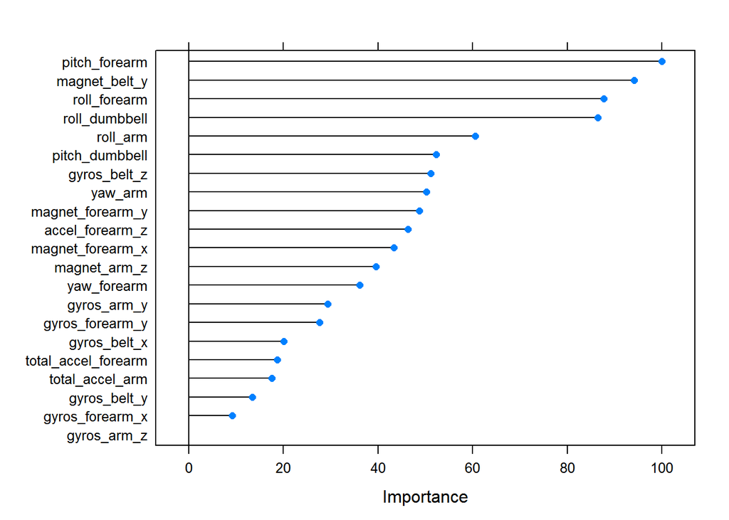

```r
plot(varImp(modRF))
```

## Prediction and Condlusion

Before we use the model to predict the validation data set, we have to pre-process the data in order to get the same size.

```r
test <- test_raw[, colnames(data[, 1:21])]

predict(modRF, test)
```

```
##  [1] B A B A A E D B A A B C B A E E A B B B
## Levels: A B C D E
```

The outcome (100% accuracy based on the Quiz session) proves that the model we created performs well, and can be used to predict the quality of weight lifts.